# NanoPlot Report

**Summary Statistics**

**Plots**

Histogram of read lengths

Histogram of read lengths after log transformation

Weighted Histogram of read lengths

Weighted Histogram of read lengths after log transformation

Yield by length

Read lengths vs Average read quality plot using dots

Read lengths vs Average read quality plot using a kernel density estimation

Aligned read lengths vs Sequenced read length plot using dots

Aligned read lengths vs Sequenced read length plot using a kernel density estimation

Read mapping quality vs Average basecall quality plot using dots

Read mapping quality vs Average basecall quality plot using a kernel density estimation

Read length vs Read mapping quality plot using dots

Read length vs Read mapping quality plot using a kernel density estimation

Percent identity vs Average Base Quality plot using dots

Percent identity vs Average Base Quality plot using a kernel density estimation

Aligned read length vs Percent identity plot using dots

Aligned read length vs Percent identity plot using a kernel density estimation

# NanoPlot report

## Summary statistics

[output not shown]

## Plots

### Histogram of read lengths

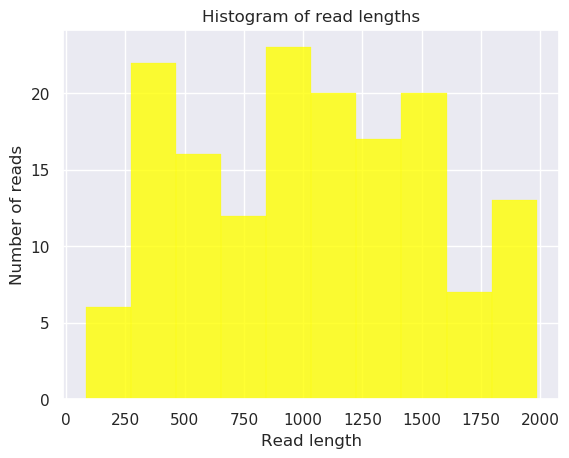

### Histogram of read lengths after log transformation

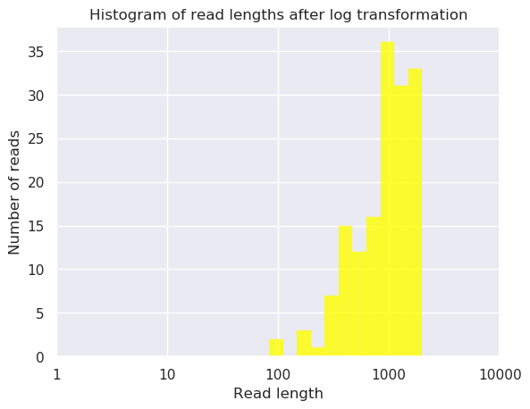

### Weighted Histogram of read lengths

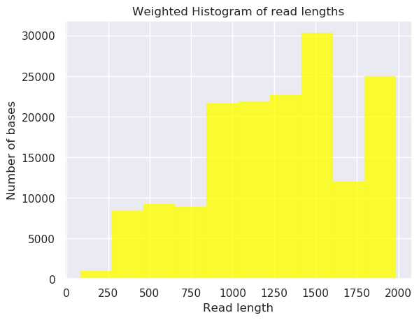

### Weighted Histogram of read lengths after log transformation

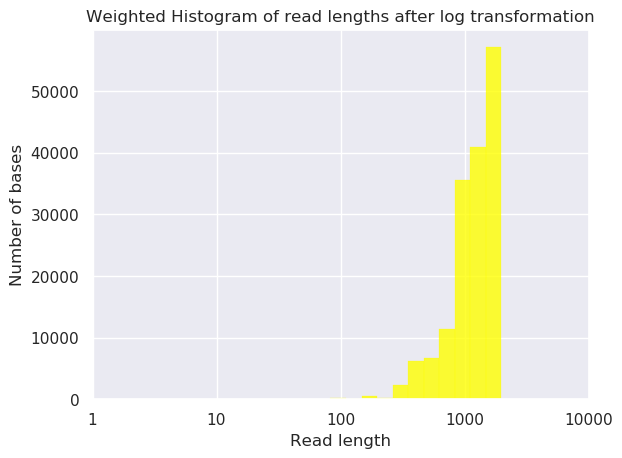

### Yield by length

[figure not shown]

### Read lengths vs Average read quality plot using dots

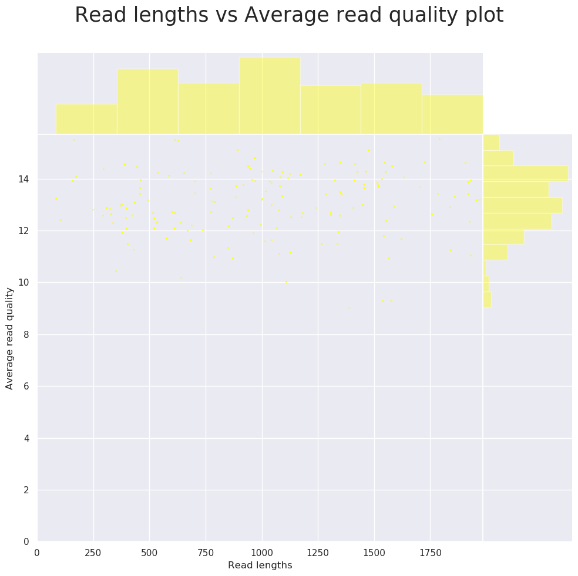

### Read lengths vs Average read quality plot using a kernel density estimation

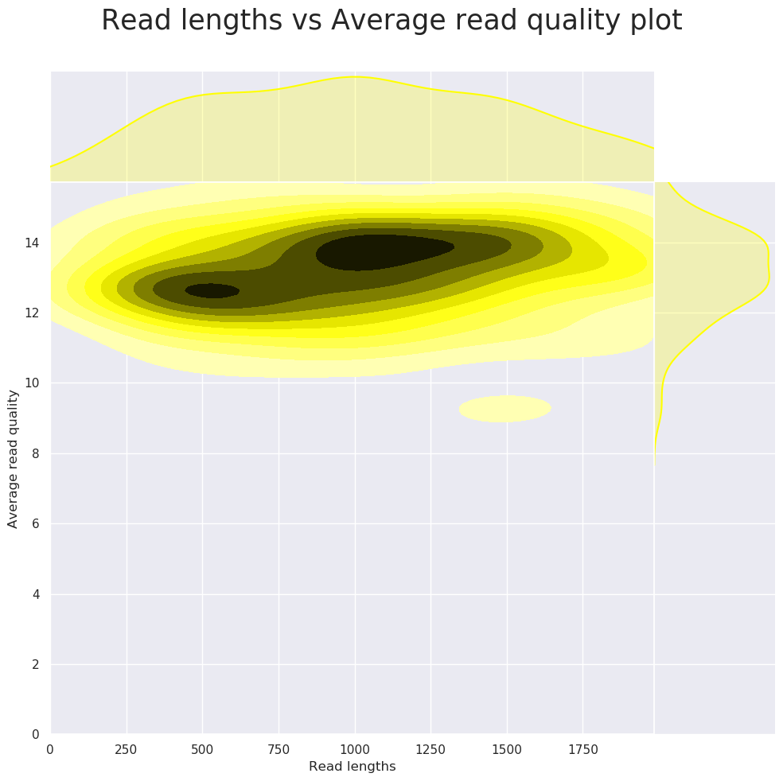

### Aligned read lengths vs Sequenced read length plot using dots

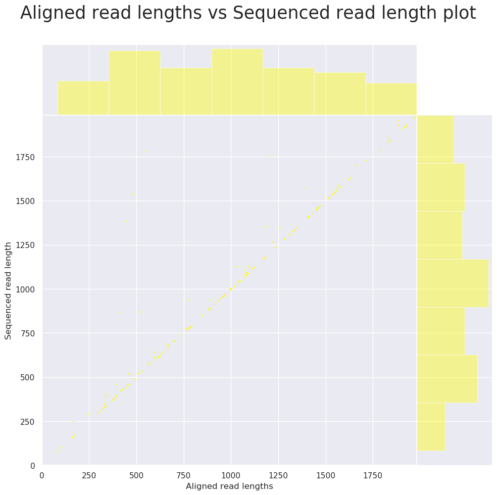

### Aligned read lengths vs Sequenced read length plot using a kernel density estimation

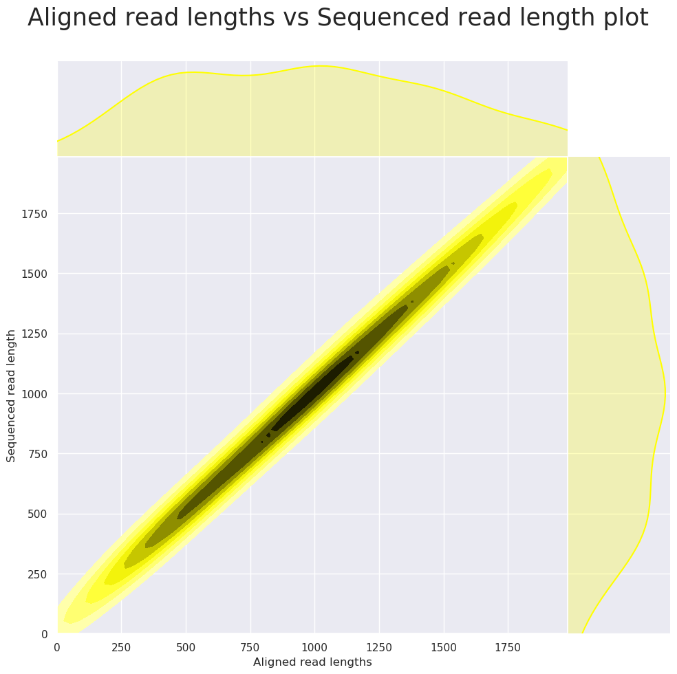

### Read mapping quality vs Average basecall quality plot using dots

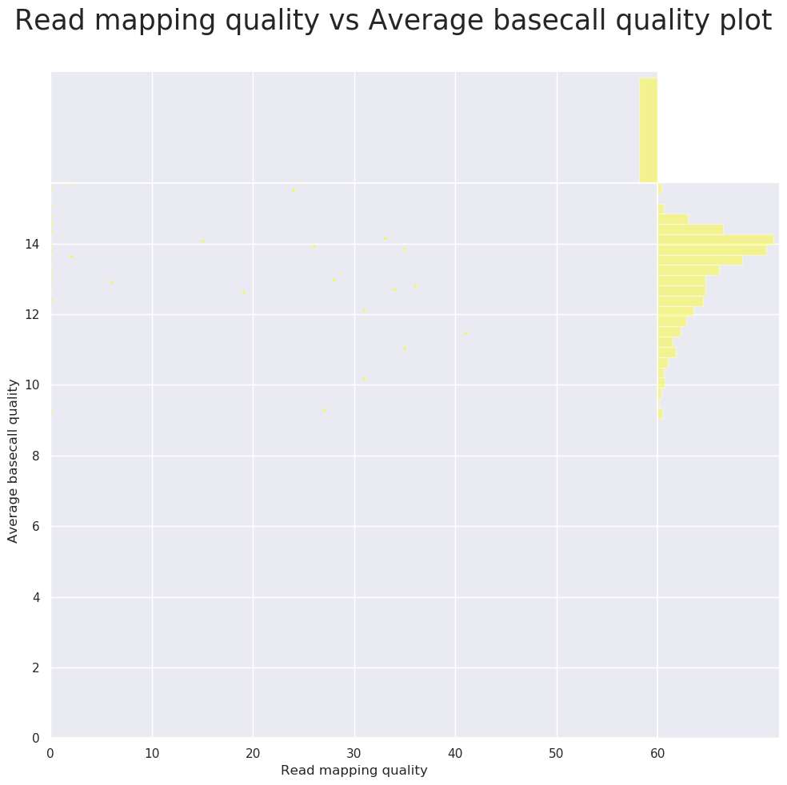

### Read mapping quality vs Average basecall quality plot using a kernel density estimation

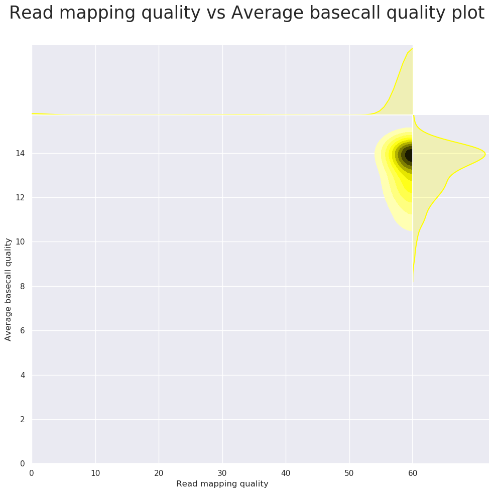

### Read length vs Read mapping quality plot using dots

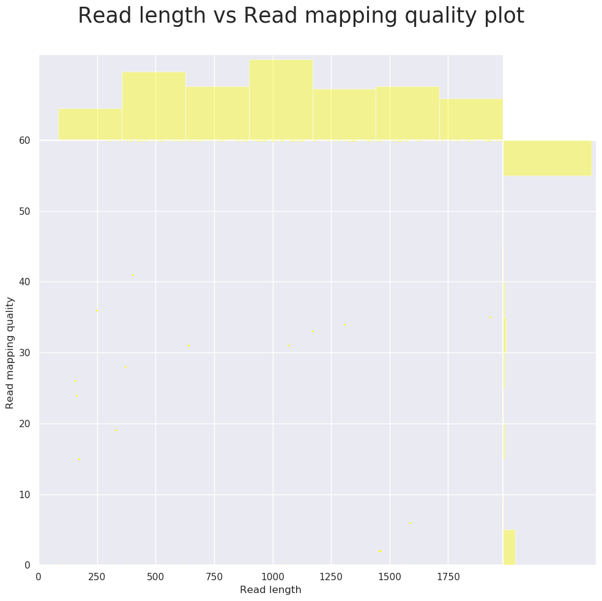

### Read length vs Read mapping quality plot using a kernel density estimation

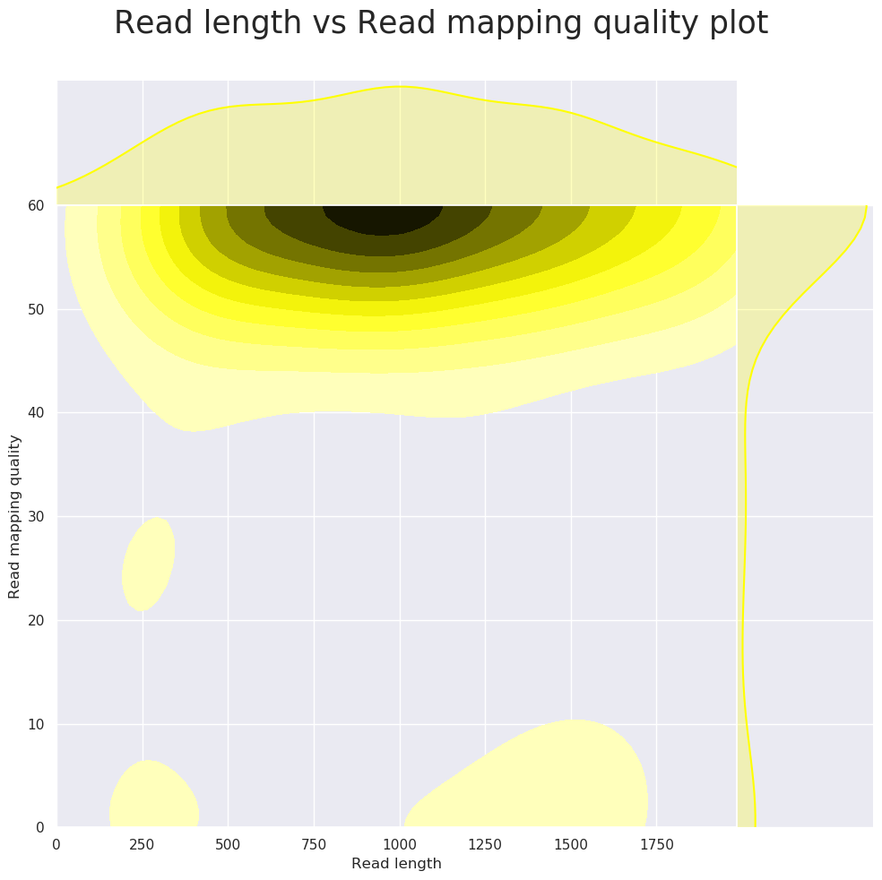

### Percent identity vs Average Base Quality plot using dots

[figure not shown]

### Percent identity vs Average Base Quality plot using a kernel density estimation

[figure not shown]

### Aligned read length vs Percent identity plot using dots

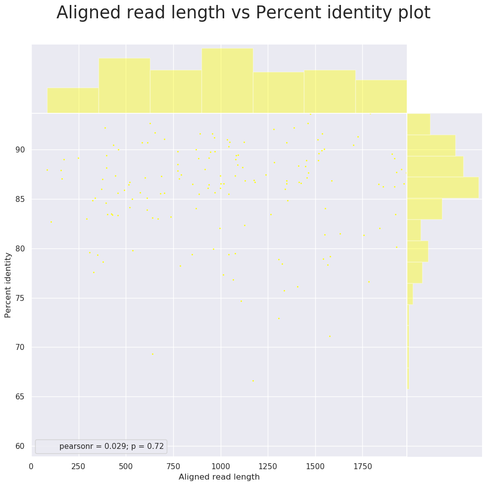

### Aligned read length vs Percent identity plot using a kernel density estimation

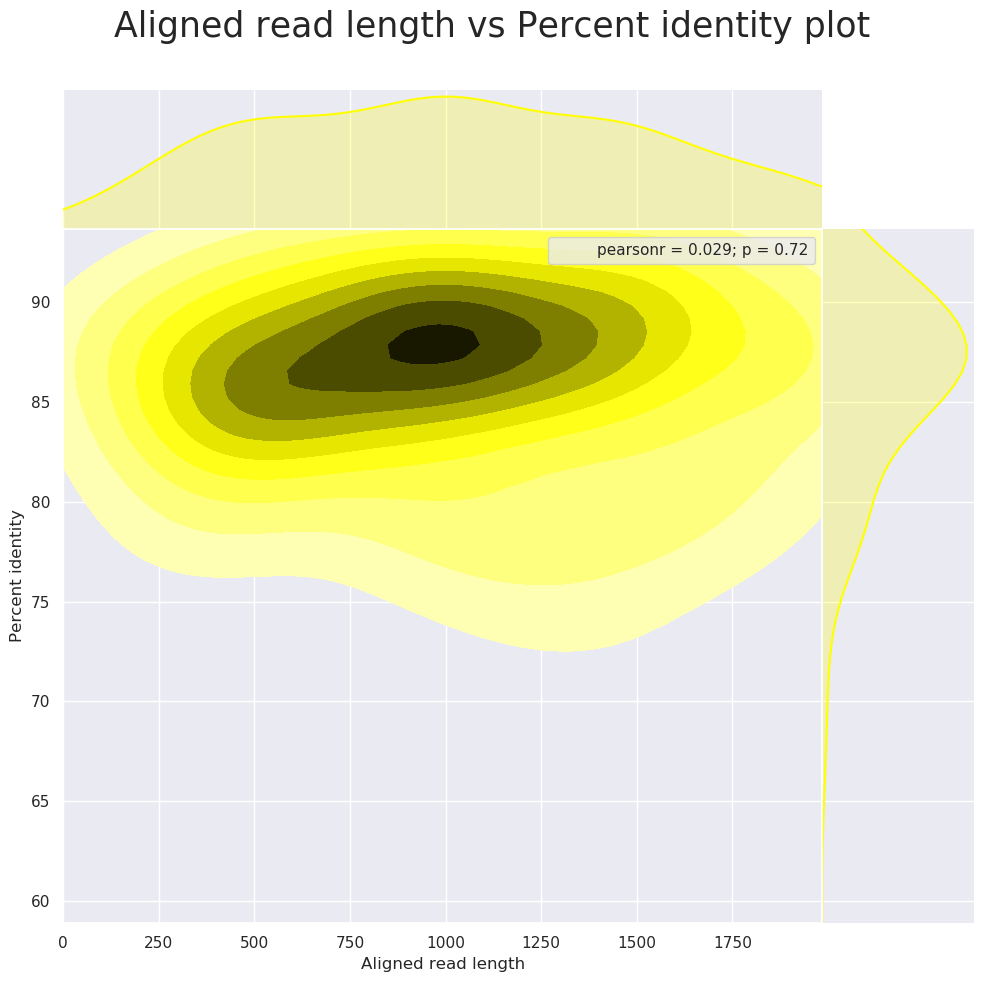